# Suicide Rates across Countries between 1985 and 2016

Gov 50 Final Project

Hailee Youn

Introduction:

According to the Centers for Disease Control and Prevention, suicide rates in the U.S. increased approximately 36% between 2000–2021 with suicide accounting for 48,183 deaths in 2021. In 2021, suicide was among the top 9 leading causes of death in the U.S.for people ages 10-64. This unfortunate reality in the U.S. is experienced worldwide with suicide rates continuing to rise. The significance of suicide research extends far beyond the statistics and numbers; it delves into the realm of human well-being, public health, and societal impact. By conducting research into the underlying causes and risk factors, we have the opportunity to develop potentially effective prevention and intervention strategies. This can save lives and alleviate the immense emotional suffering experienced by individuals, families, and communities affected by suicide.

I became interested in exploring how factors such as a country’s GDP per capita, gender, age, and generation may influence or have a relationship with suicide rates. I recently read an interesting paper published by the National Institute of Health in February of 2022, entitled “The impact of macroeconomic factors on suicide in 175 countries over 27 years.” The results of this study stated that for every 1000 US dollar increase in the GDP per capita, suicide rates are reduced by 2% (RR = 0.98 [0.98–0.98]), corresponding to a reduction of 14,000–15,000 suicide deaths per year globally. The implications of these results are staggering, suggesting that even relatively modest improvements in economic conditions could lead to a substantial reduction in the global burden of suicide, potentially saving tens of thousands of lives each year. Upon reading this literature, I decided to conduct this final project, focusing on investigating the relationship between GDP per capita and suicide rates. Based on the previous literature, I hypothesize that as GDP per capita rises, suicide rates will exhibit a corresponding decline.

Data:

My data was a compiled dataset pulled from four other data sets linked by time and place, downloaded from the platform “Kaggle.” The data draws from censuses and open publications such as the United Nations Development Program and World Health Organization, which provide demographic information about suicide incidents worldwide.

The key dependent variable in this analysis is the “suicides.100k.pop,” which represents the number of suicides per population of 100,000 people. This variable measures the prevalence of suicide within a population, providing insight into suicide rates on a per capita basis. The key independent variable is “gdp_per_capita ($),” which quantifies the GDP per capita for each country in US dollars. GDP per capita serves as an indicator of a country’s economic well-being and is used in this analysis as a potential predictor of suicide rates. Both of these variables were collected at the country level, covering multiple years, and were recorded through established statistical methods and data collection processes. The data sources and measurement methods for these variables are well-documented by WHO and UN, ensuring their reliability and validity for the purposes of this analysis.

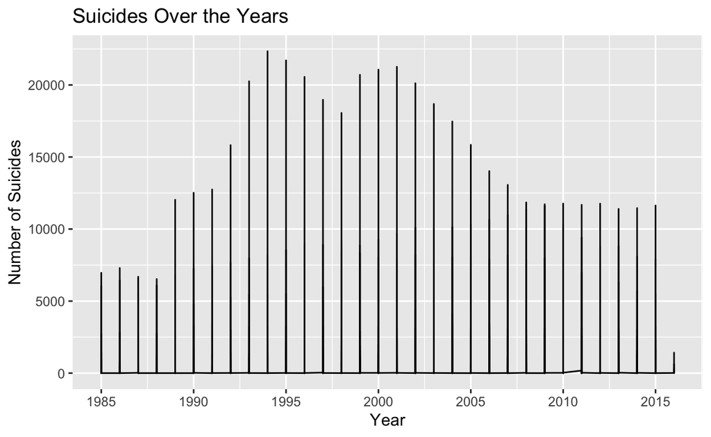

The first graph I created was a line plot illustrating the cumulative count of suicides from 1985 to 2016 across all the countries within the data set. This graphical representation offered a big-picture insight into the pattern of suicide rates over the years. The line plot demonstrates that suicide rates were notably lower at the tail ends of when the data was collected in 1985 and 2016. Between those two years, suicide rates have fluctuated with notably high rates in 1994 and 2001. Between the years 2008 and 2015, suicide levels were pretty consistent year to year. It is worth noting that because the data was collected in 2016, the entirety of suicide occurrences in 2016 was not accounted for by this data set, which is why the suicide count dipped in 2016.

Results:

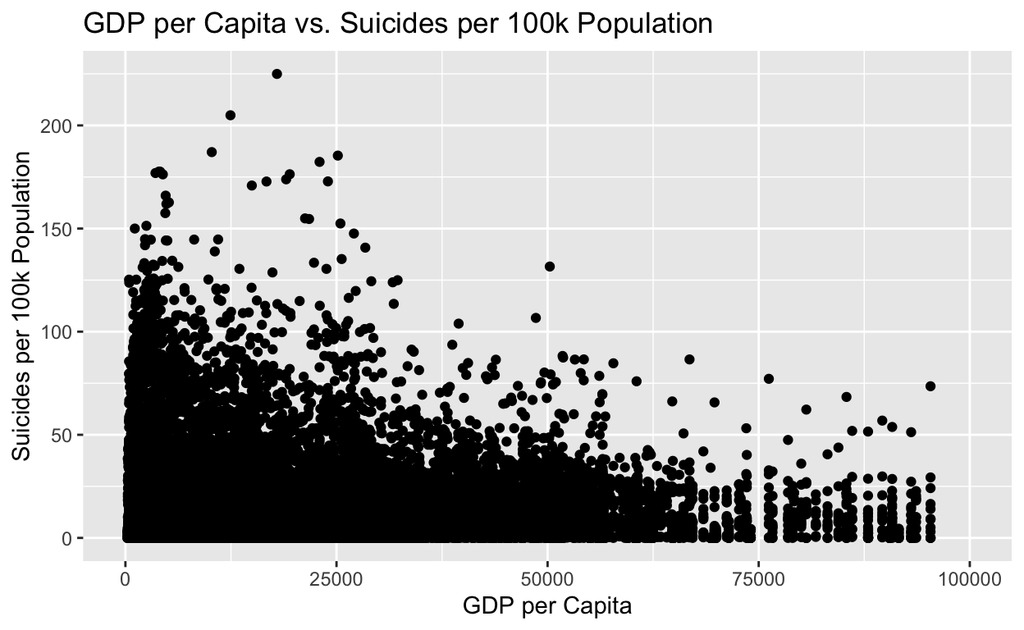

```
=====================================================
                              Dependent variable:
                          ---------------------------
                               suicides.100k.pop
-----------------------------------------------------
gdp_per_capita....                0.00002***
                                   (0.00001)

age25-34 years                     3.521***
                                    (0.401)

age35-54 years                     6.836***
                                    (0.624)

age5-14 years                      -8.937***
                                    (0.415)

age55-74 years                     8.971***
                                    (0.936)

age75+ years                       16.601***
                                    (1.087)

sexmale                            14.846***
                                    (0.191)

generationG.I. Generation           -0.123
                                    (0.823)

generationGeneration X               0.540
                                    (0.479)

generationGeneration Z              2.415**
                                    (1.053)

generationMillenials                 0.936
                                    (0.737)

generationSilent                   -1.434***
                                    (0.535)

year                               -0.123***
                                    (0.023)

Constant                          246.927***
                                   (44.632)

-----------------------------------------------------
Observations                        27,820
R2                                   0.296
Adjusted R2                          0.296
Residual Std. Error           15.908 (df = 27806)
F Statistic               901.426*** (df = 13; 27806)
=====================================================
Note:                     *p<0.1; **p<0.05; ***p<0.01
```

The main coefficient of interest is the one associated with “gdp_per_capita….”, which has an estimated coefficient of approximately 0.00002 with a standard error of approximately 0.00001. The p-value for this coefficient is 0.00189, denoted as ’***,’ which signifies statistical significance at the significance level of 0.05.

Although the statistical analysis shows that the coefficient is statistically significant, it’s important to emphasize that this does not imply a direct causal relationship between an increase in GDP per capita and a rise in the suicide rate as correlation does not imply causation. Furthermore, given the relatively weak association observed between GDP per capita and the occurrence of suicides, it is difficult to make definitive statements about the extent of their connection.

The adjusted R-squared value (0.2962) provides information about how well the entire regression model explains the variation in suicide rates. In this case, the model explains approximately 29.62% of the variance in suicide rates.

When looking at the scatter plot, there appears to be a negative correlation between GDP per capita and suicide but upon running the regression, we see that the opposite effect is present. This highlights the importance of controlling for confounding variables and being aware of any external factors that may influence the graphic result.

Interestingly, among the controlled variables in the regression analysis, several exhibit statistical significance and relatively large coefficients. For instance, the variables related to different age groups, such as “age25-34 years,” “age35-54 years,” “age5-14 years,” “age55-74 years,” and “age75+ years,” all show strong statistical significance with large coefficients. This suggests that age group composition plays a significant role in explaining variations in suicide rates. Similarly, the variable “sexmale” (representing male gender) also has a highly significant coefficient, indicating a strong association between gender and suicide rates. Additionally, the variable “year” exhibits statistical significance, suggesting that the year in which data was recorded has an impact on suicide rates. These findings indicate that factors related to age, gender, and time may be important contributors to suicide rates and warrant further exploration.

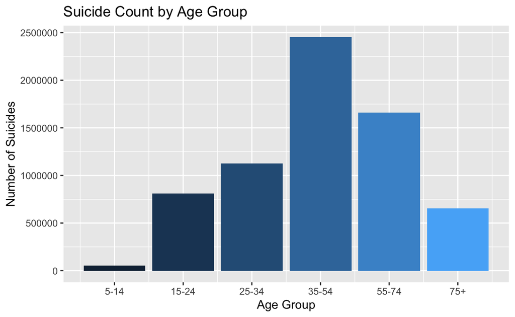

In addition to exploring whether there was a relationship between GDP per capita and suicide occurrences, I was curious to conduct additional analyses of the data. I created a bar graph show the number of suicide incidences, split by age groups. The bar group appears to have a normal distribution with a lower suicide counts on the tail ends of the age groups and peaking within the 35-54 year-old age group.

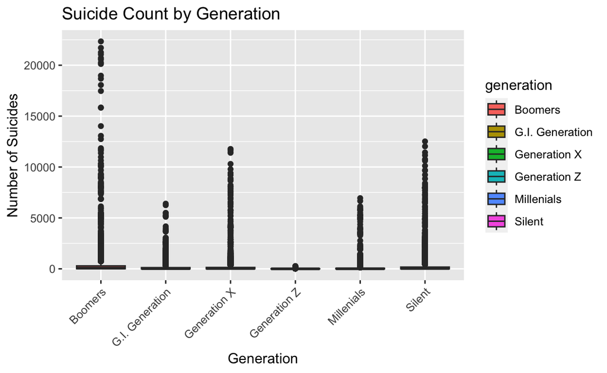

For the last graph, I produced a box plot, portraying suicide occurrences based on the different generation categories (i.e. Boomers, GenZ, Millenials, etc.). This graphic was very interesting as it is reflective of suicide rates among specific generations, perhaps indicating socio-cultural norms of the given generation. Among the generations, it is apparent that Boomers committed the highest count of suicide while Generation Z committed the fewest count. If I had the time and resources to continue with this project, I would be interested in further parsing out this data and assessing when each of these members of the generation committed suicide. Given that Boomers are older than Generation Z, the result may be inaccurately portraying Generation Z as a generation of less suicide when in reality, the generation has not lived long enough to reach the high-suicide-rate ages.

Conclusion:

Upon conducting an analysis of the data, I am unable to support my original hypothesis that as GDP per capita rises, suicide rates will exhibit a corresponding decline. One limitation of this data set is that it focuses on the aggregate GDP per capita of countries rather than providing specific information about the countries where suicides occurred and the socioeconomic status of the individuals involved. The GDP of the country may not necessarily be reflective of suicide victims’ individual financial situations and therefore not have a relationship with suicide rates. Thus, if I were to replicate this study, I would be interested in comparing suicide rates with individuals’ income, rather than GDP per capita. Furthermore, I think this analysis could be improved with supplementary study of longitudinal data to explore causality and the dynamics of this relationship over time. We would also consider incorporating additional relevant variables and conducting more detailed subgroup analyses to better understand the nuances of the relationship between GDP per capita and suicide rates. If time and funds allowed, conducting surveys or collecting more granular data at the individual level would provide a more comprehensive view of the factors contributing to suicide. While the data spans from 1985 to 2016, the literature I read prior to conducting this study indicates that suicide rates worldwide are continuing to climb. If more recent and updated data were published, I would like to integrate the new years into this analysis as well.

As a by-product of generating my regression and discovering the lack of a strong relationship between GDP per capita and suicide, I discovered large coefficient values (both positive and negative) with statistically significant corresponding p-values for the variables of age and sex of the suicide victims. This highlights that further investigations into factors that may be correlated with suicide–even within the breadth of this data set–can be fruitful. Additionally, we do not have information on potential confounding variables, such as mental health services availability, cultural factors, or other socioeconomic indicators that could impact suicide rates. Assessing these additional factors and their relationship with suicide rates would also be meaningful to explore.